# Single-Cell Omics Research and Education

#### 6.2.2.1 Output folder structure (Cell Ranger)

Cell Ranger generates several files and folders after processing single-cell RNA-seq data. The key outputs are:  
https://www.10xgenomics.com/support/software/cell-ranger/latest/analysis/outputs/cr-outputs-gex-overview

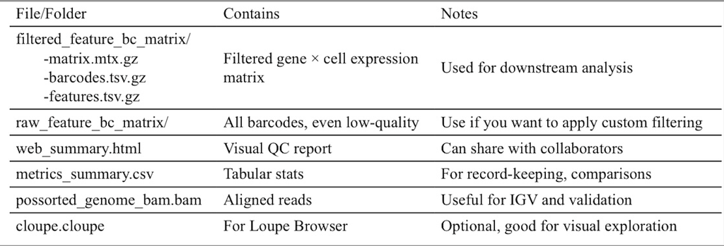

Outputs compatible with Seurat, Scanpy, IGV, and downstream tools  
Can be used with CellBender, Alevin, or custom workflows  
**A) Filtered Feature Matrix (typically under outs/filtered_feature_bc_matrix/):**

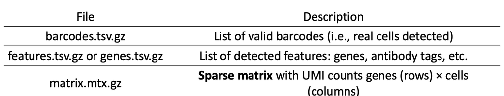

Output file format: Which one should you use? MEX vs HDF5 (.h5)?  
Both formats contain the same information:  
A gene × cell expression matrix, with barcodes and features.  
The difference is in the file structure and format:

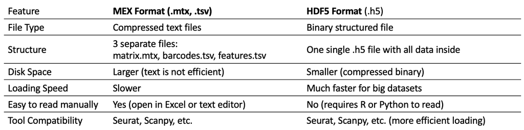

**B) raw_feature_bc_matrix/**  
- Same structure as filtered_feature_bc_matrix, but:  
- Includes all barcodes, even: Empty droplets, Damaged cells, Low-quality barcodes  
Why is it useful?  
Re-analyze using your own custom filtering, Identify ambient RNA contamination

**C) QC and Summary Reports:**  
- web_summary.html: Interactive summary with plots (genes per cell, mitochondrial %, etc.)  
An interactive report viewable in any browser. Shows:  
- Total number of estimated cells  
- Reads per cell  
- Median genes per cell  
- % mitochondrial gene expression  
- Sequencing saturation  
- Clustering preview (if applicable)  
- Useful for checking: If the run worked, How deep was the sequencing, General quality of data (need it for publishing)  
- metrics_summary.csv: Tabular summary of sequencing and mapping statistics

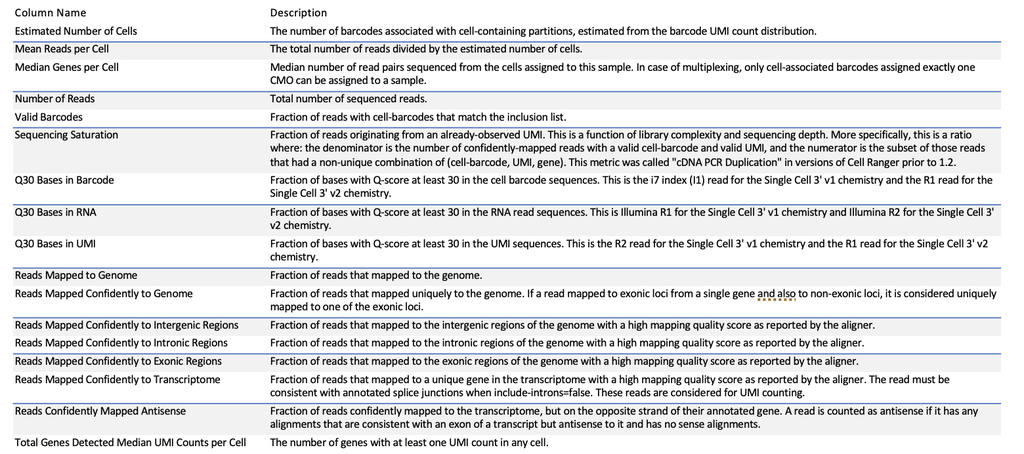

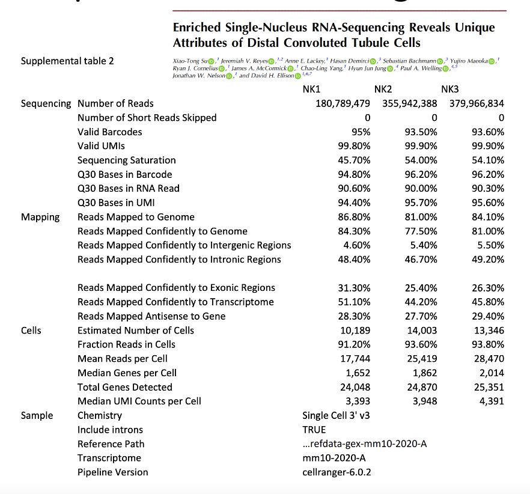

**D) BAM (Binary Alignment/Map) Files:** possorted_genome_bam.bam and .bam.bai  
- BAM files = aligned reads in binary format  
- `possorted_genome_bam.bam`: aligned + unassigned reads (incl. Feature Barcode libs)  
- `unassigned_alignments.bam` / `sample_alignments.bam`: unassigned vs. assigned reads  
- Use: troubleshoot, reconvert to FASTQ, explore in IGV (includes barcodes)  
**E) cloupe.cloupe:**  
- `.cloupe`: binary file for Loupe Cell Browser (by 10X Genomics)  
- Allows: cluster exploration, gene expression per cluster, manual annotation, marker analysis  
- Optional, but useful for biologists and presentations  
[More info](https://www.10xgenomics.com/support/software/loupe-browser/latest)

### 6.2.3 Downstream Analysis (Seurat, etc.)

Processed Data Formats:  
- .rds (Seurat): Includes count matrix, metadata, UMAP, clusters  
- .h5ad (Scanpy): Same as above but in Python format  
- metadata.csv: Per-cell information (cluster, % mito, etc.)  
- degs.csv: Differentially expressed genes between clusters or conditions  
- umap.png, violin_plot.png: Visual outputs from analysis

### 6.2.4 Optional(?) Files & Documentation for Project SharingOptional Files

These files help others understand, run, and reproduce your project (on GitHub or similar platforms).

#### 6.2.4.1 Projects should include additional files to support:

- Data Sharing: Make your datasets accessible (e.g., via GEO or public repositories).
- Reproducibility: Include scripts and environment files to allow others to rerun your analysis exactly.
- Collaboration: Clear documentation helps others understand and contribute to your project.

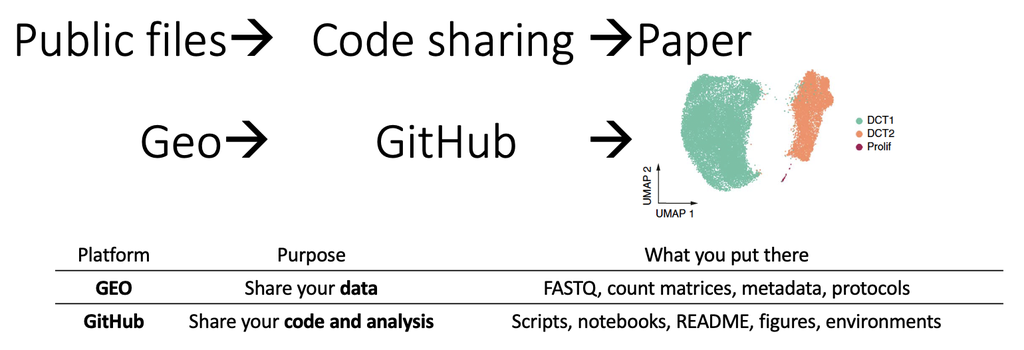

## 6.3 Data: GEO (Gene Expression Omnibus) – Public data sharing platform for genomics

### 6.3.1 What is GEO?

GEO is a public repository managed by the NCBI (National Center for Biotechnology Information).  
It’s used to store and share high-throughput gene expression data, including:  
- Microarray  
- Bulk RNA-seq  
- Single-cell/snRNA-seq  
- Multi-modal (CITE-seq, spatial transcriptomics)

- Journals often require data in public archives like GEO
- GEO ensures compliance, reproducibility, sharing, and reuse

### 6.3.2 What’s included in a typical GEO submission?

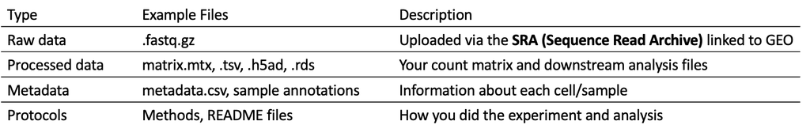

### 6.3.3 Submitting a Dataset to GEO

**Steps:** 1. Create `Meta.data` sheet  
2. Organize files and get MD5 checksums:  
• FASTQ, matrix, `.rds`  
3. Upload files via NCBI account  
4. Add GEO link and reviewer token to Methods section in your manuscript

> *Tip:* GEO staff is very helpful—especially if you make a mistake!

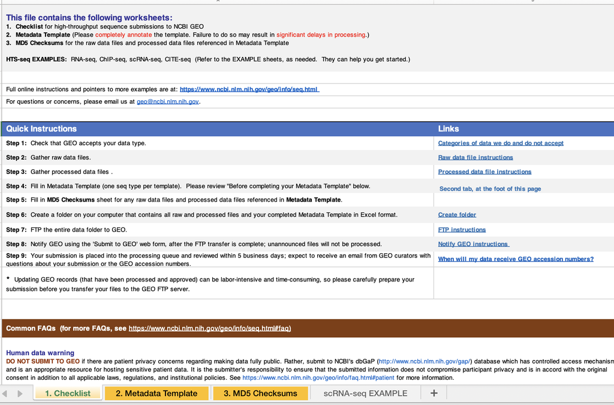

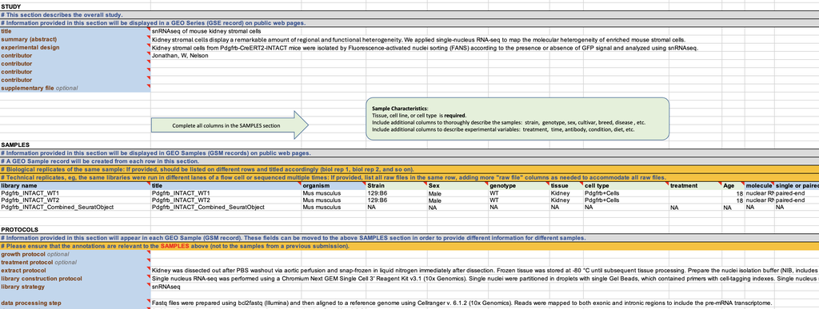

#### 6.3.3.1 **Files** to **Download**

[**2025** Template Submission file from GEO](https://docs.google.com/spreadsheets/d/1CoMp-hg8-DwjmQ6T6QPri0rnnx5gOCvL/edit?usp=sharing&ouid=100835342690409949441&rtpof=true&sd=true)

[Filled out **example** of the GEO submission file](https://docs.google.com/spreadsheets/d/1nmgVc4ADKIYqjepmkCkCMIxX-xBNiiif/edit?usp=sharing&ouid=100835342690409949441&rtpof=true&sd=true)

#### 6.3.3.2 Set a release date

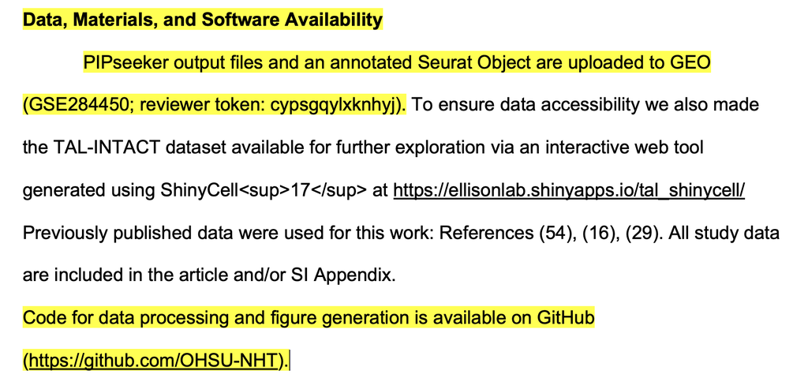

[figure not shown]

### 6.3.4 Where to find GEO in papers?

https://www.ncbi.nlm.nih.gov/geo/

[figure not shown]

### 6.3.5 **GEO Structure: The 3 layers**

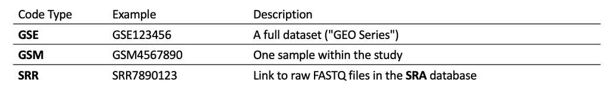

#### 6.3.5.1 .tar files

A .tar file is an archive format that bundles multiple files and folders into a single file, without compressing them.  
Think of it like un ZIP file, but without compresión por defecto.  
Very common in Linux/Unix systems and in bioinformática para packaging datasets.

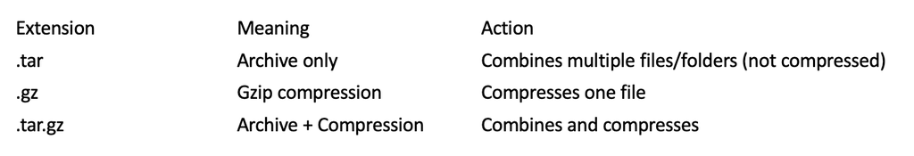

#### 6.3.5.2 .rds files

[figure not shown]

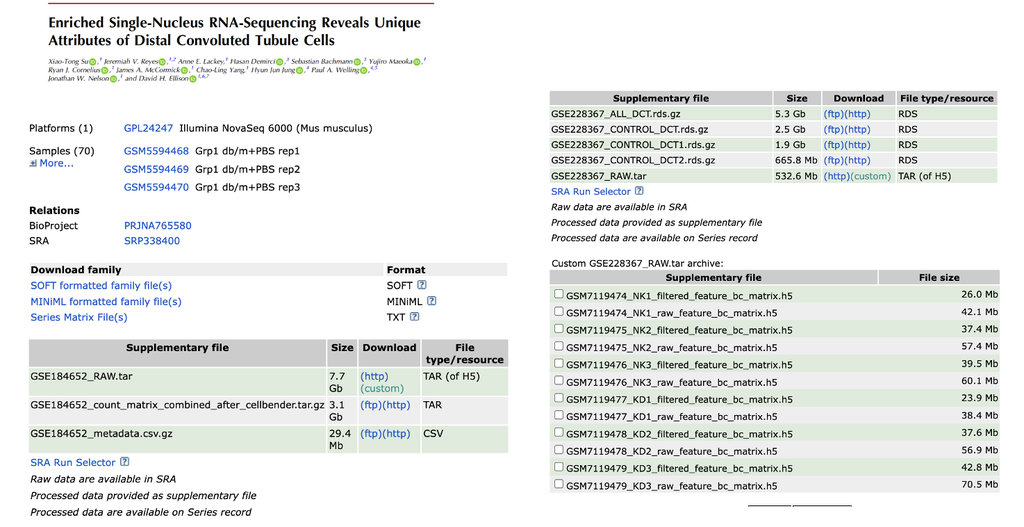

## 6.4 Sharing Code

### 6.4.1 GitHub – Code, documentation, and collaboration platform

[figure not shown]

### 6.4.2 What is GitHub?

GitHub is a version-controlled code hosting platform.  
It’s perfect for managing your analysis scripts, notebooks, and documentation.  
It’s built on Git, which allows you to track every change you make to a file.  
Use GitHub Releases to tag versions (e.g., “v1.0 – preprint version”)  
Add a LICENSE (Reference) file to clarify how others can use your code  
Add badges (optional) to show R/Python versions, citation info, etc.

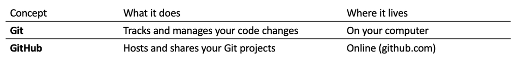

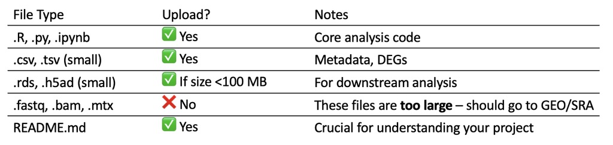

### “Typical” GitHub Repo Structure for Single-Cell Analysis

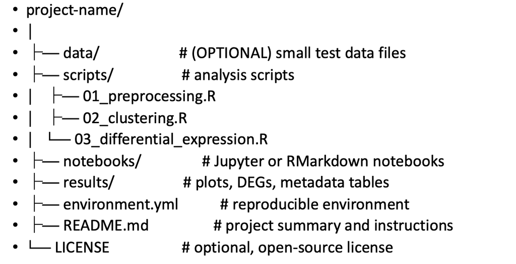

### 6.4.3 https://github.com/OHSU-NHT/Su_dct_2023

[figure not shown]

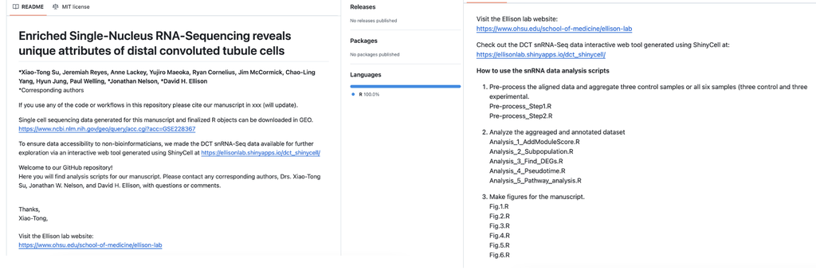

[figure not shown]

## 6.5 Shiny App

### 6.5.1 What is a Shiny App?

A Shiny App is an interactive web application built using the R programming language. It allows you to turn your R scripts, data visualizations, and statistical models into una interfaz web, sin necesidad de escribir HTML, JavaScript o CSS.

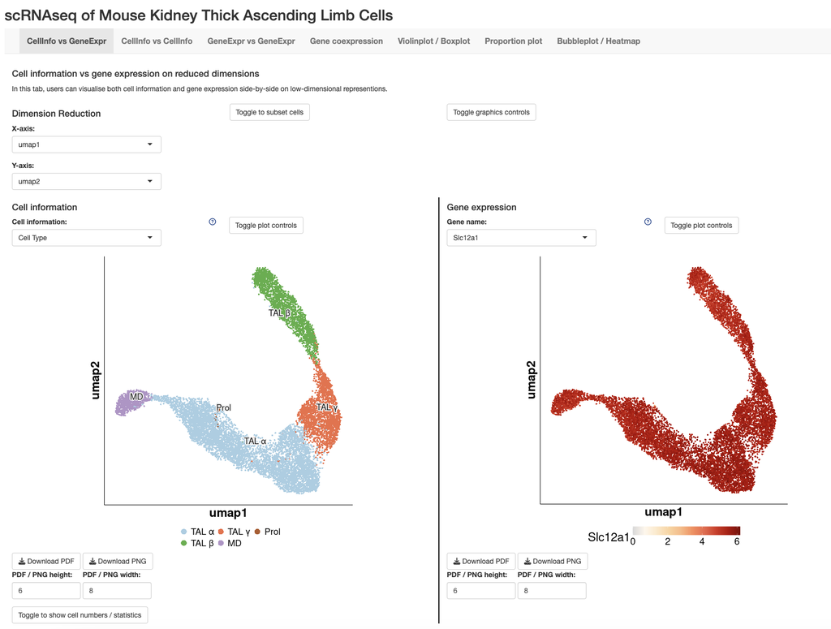

### 6.5.2 Why is it useful in single-cell/snRNA-seq analysis?

A Shiny App lets scientists, clinicians, and collaborators (even without coding skills):  
- Explore clusters and cell types  
- Visualize marker gene expression  
- Interact with UMAP or t-SNE plots  
- Compare experimental conditions  
- Download plots or data tables

It transforms static results into an interactive data exploration tool.

### 6.5.3 How does it work?

- Perform your analysis in R (e.g., using Seurat)
- Build the interface and logic using the `shiny` package
- The app runs as a web page—no coding required for end users

https://ellisonlab.shinyapps.io/dct_shinycell/  
https://ellisonlab.shinyapps.io/tal_shinycell/

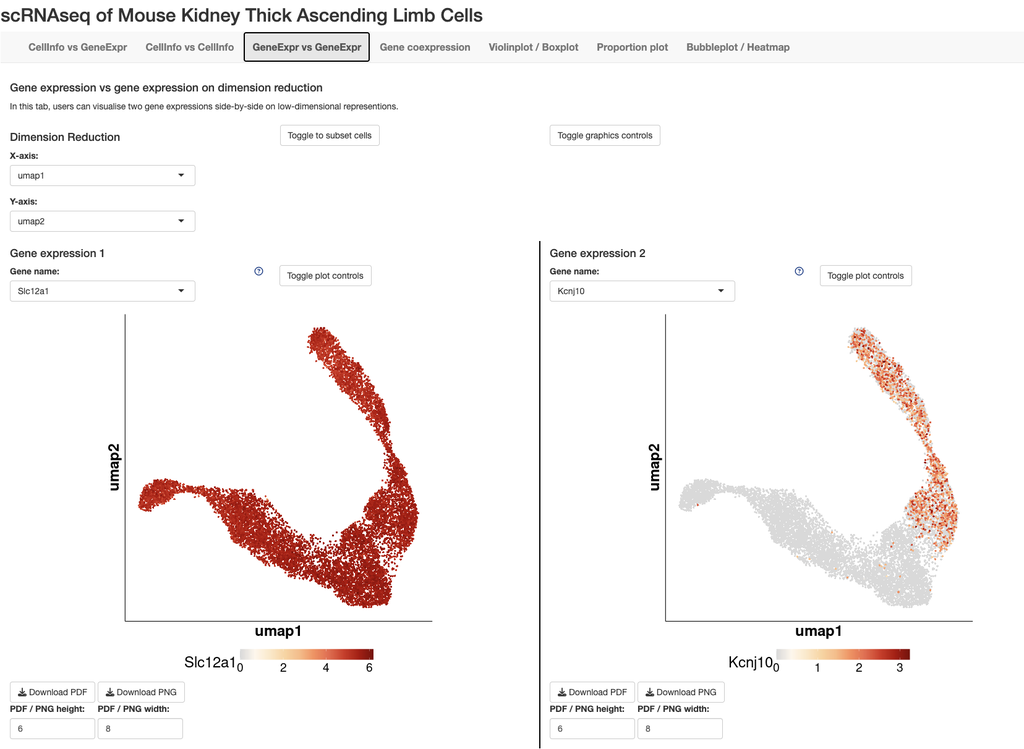

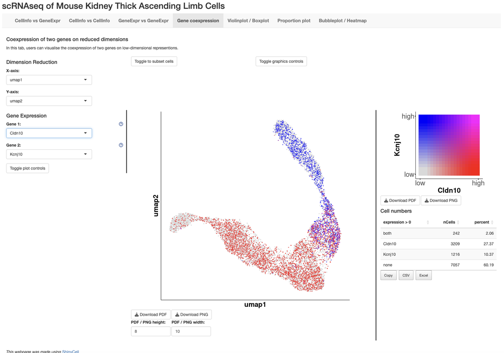

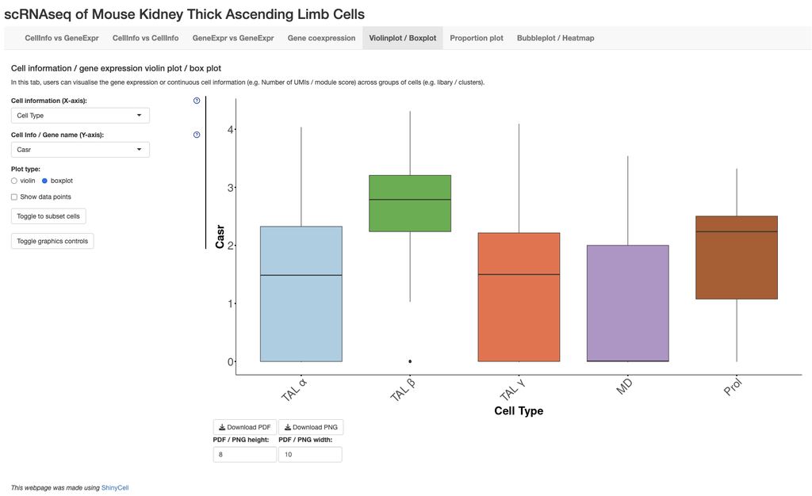

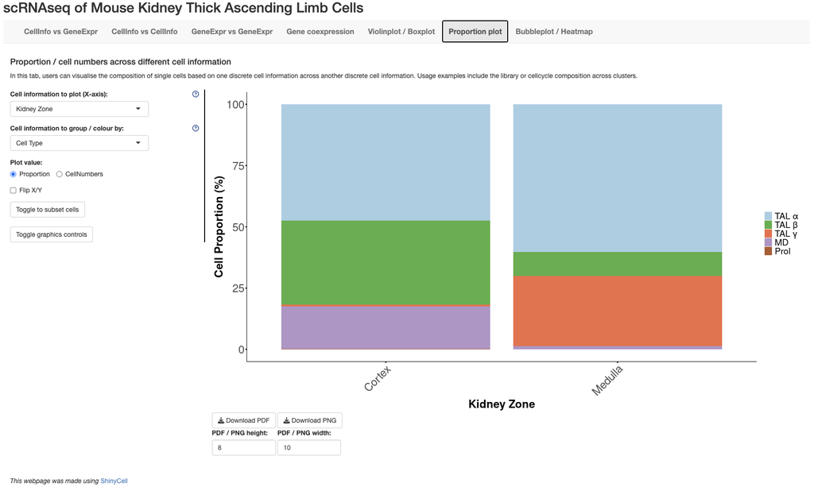

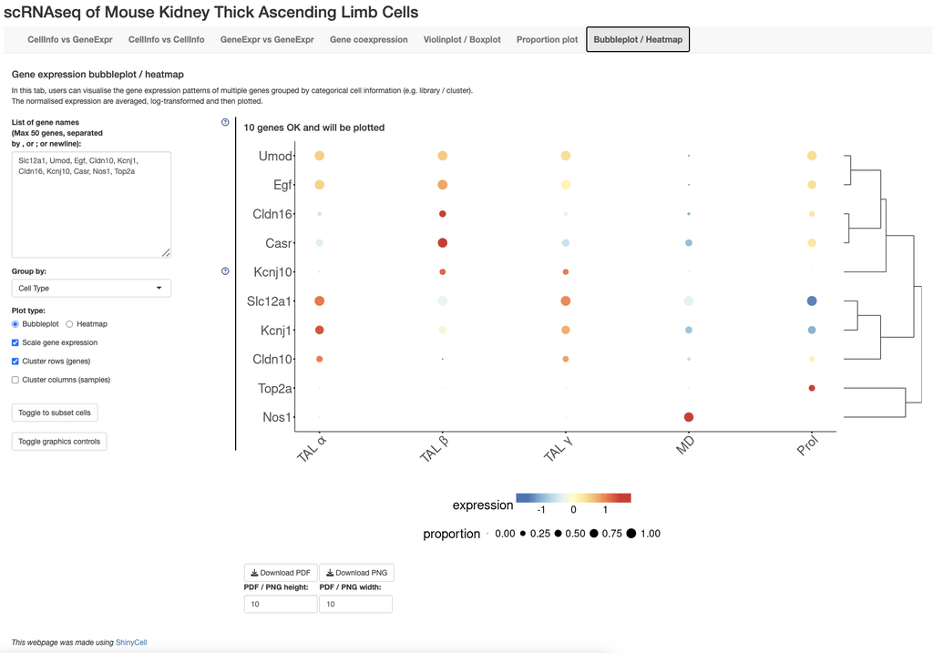

## 6.6 Thank you for your attention!!

# 7 Closing Remarks

I hope that you found this session helpful.

## 7.1 Would anyone else like to **share their experience with reporting omics data**?

## 7.2 Questions?

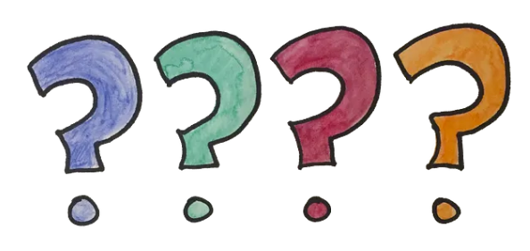

## 7.3 Community Questions

Do you have a **coding problem** that you’d like some support on?  
Do you have a **topic** you’d like covered at a future meeting?

## 7.4 Upcoming Schedule

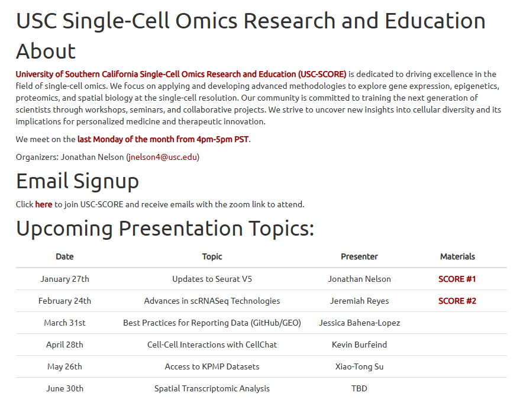